# DS202: Lab 4

MyTien Kien; kmytien

3/16/2021

```r
library(readxl)
library(dplyr)
library(tidyr)
library(ggplot2)
```

```r
defense <-  read_excel('C:\\Users\\kmyti\\OneDrive\\Desktop\\ds202_excel\\cyclonesFootball2020.xlsx', sheet='Defensive')
offense <-  read_excel('C:\\Users\\kmyti\\OneDrive\\Desktop\\ds202_excel\\cyclonesFootball2020.xlsx', sheet='Offensive')
bio <-  read_excel('C:\\Users\\kmyti\\OneDrive\\Desktop\\ds202_excel\\cyclonesFootball2020.xlsx', sheet='Biography')
```

## Part 1: Cleaning

```r
#Factored and converted necessary columns to numeric for Defense and Offense
defClean <- defense %>%
      mutate(Name = factor(Name)) %>%
      mutate(Opponent_Opponent = factor(Opponent_Opponent)) %>%
      mutate(across(3:11, as.numeric))

offClean <- offense %>%
      mutate(Name = factor(Name)) %>%
      mutate(Opponent_Opponent = factor(Opponent_Opponent)) %>%
      mutate(across(3:12, as.numeric))
#For Bio, I converted height into inches, as well as factored Name and turned Weight numeric
bio <- bio %>%
      mutate(Name = factor(Name)) %>%
      mutate(Weight = as.numeric(Weight))

bioClean <- bio %>%
      separate(Height, into = c("Ft", "In"), convert = TRUE) %>%
      mutate(Height = (Ft * 12) + In) %>%
      select(-c(Ft:In))

#Printing Structures
str(defClean)
```

```
## tibble [372 x 11] (S3: tbl_df/tbl/data.frame)
##  $ Name             : Factor w/ 37 levels "Akers, Landen",..: 26 26 26 26 26 26 26 26 26 26 ...
##  $ Opponent_Opponent: Factor w/ 11 levels "Baylor","Kansas",..: 4 8 5 10 6 2 1 3 9 11 ...
##  $ Tackles_Solo     : num [1:372] 2 6 6 3 7 4 7 4 4 2 ...
##  $ Tackles_ASST     : num [1:372] 4 4 5 0 3 1 4 3 9 3 ...
##  $ Tackles_TFL      : num [1:372] 1 0 1.5 1 1 0 1.5 2.5 1.5 0 ...
##  $ Tackles_Sack     : num [1:372] 0 0 0.5 0 0 0 0 1 0 0 ...
##  $ Turnover_FF      : num [1:372] 0 0 0 0 0 0 0 0 0 0 ...
##  $ Turnover_FR      : num [1:372] 0 0 0 0 0 0 0 0 0 0 ...
##  $ Turnover_INT     : num [1:372] 0 1 0 0 1 0 1 1 0 0 ...
##  $ Pass_QBH         : num [1:372] 0 0 1 0 0 0 2 1 0 0 ...
##  $ Pass_PB          : num [1:372] 0 0 0 0 0 1 0 0 1 0 ...
```

```r
str(offClean)
```

```
## tibble [156 x 12] (S3: tbl_df/tbl/data.frame)
##  $ Name             : Factor w/ 16 levels "Akers, Landen",..: 1 1 1 1 1 1 1 1 1 1 ...
##  $ Opponent_Opponent: Factor w/ 11 levels "Baylor","Kansas",..: 4 8 5 10 6 2 1 3 9 11 ...
##  $ Receiving_REC    : num [1:156] 0 2 1 4 0 6 1 0 1 1 ...
##  $ Receiving_YDS    : num [1:156] 0 60 35 34 0 76 11 0 10 2 ...
##  $ Receiving_TD     : num [1:156] 0 0 0 0 0 0 0 0 0 1 ...
##  $ Rushing_ATT      : num [1:156] NA NA NA NA NA NA NA NA NA NA ...
##  $ Rushing_YDS      : num [1:156] NA NA NA NA NA NA NA NA NA NA ...
##  $ Rushing_TD       : num [1:156] NA NA NA NA NA NA NA NA NA NA ...
##  $ Passing_CMP-ATT  : num [1:156] NA NA NA NA NA NA NA NA NA NA ...
##  $ Passing_YDS      : num [1:156] NA NA NA NA NA NA NA NA NA NA ...
##  $ Passing_TD       : num [1:156] NA NA NA NA NA NA NA NA NA NA ...
##  $ Passing_INT      : num [1:156] NA NA NA NA NA NA NA NA NA NA ...
```

```r
str(bioClean)
```

```
## tibble [116 x 7] (S3: tbl_df/tbl/data.frame)
##  $ Name      : Factor w/ 116 levels "Akers, Landen",..: 1 2 3 4 5 6 7 8 9 10 ...
##  $ Position  : chr [1:116] "Wide Receiver" "Tight End" "Wide Receiver" "Defensive Back" ...
##  $ Weight    : num [1:116] 191 240 208 180 195 199 253 261 288 182 ...
##  $ Class     : chr [1:116] "Redshirt Senior" "Redshirt Senior" "Redshirt Freshman" "Freshman" ...
##  $ Hometown  : chr [1:116] "Cedar Rapids, Iowa" "Nixa, Mo." "Seffner, Fla." "Ft. Lauderdale, Fla." ...
##  $ Highschool: chr [1:116] "Washington" "Nixa" "Armwood" "Cardinal Gibbons" ...
##  $ Height    : num [1:116] 72 79 77 72 72 72 75 74 74 74 ...
```

For defClean & offClean, I converted the Name & Opponent so that it is factored, and everything else is numeric. For bioClean, I factored the Name as well as turned Weight numerical. For The Height in bioClean, I chose to convert the height into inches.

## Part 2: Tidying

**1.** Reformat the offClean data frame into a tidy format using pivot_longer. The type of statistic (Receiving_REC for the number of receivings, Receiving_YDS for receiving yards) is added as a new key column named stat.

```r
p_one <- offClean %>%
      pivot_longer(c(3:12), names_to = "Stat", values_to = "Value")
```

**2.** Show on the distributions of the offensive statistics. The distribution of each offensive statistic should be shown in a separate facet. Explain the patterns you see.

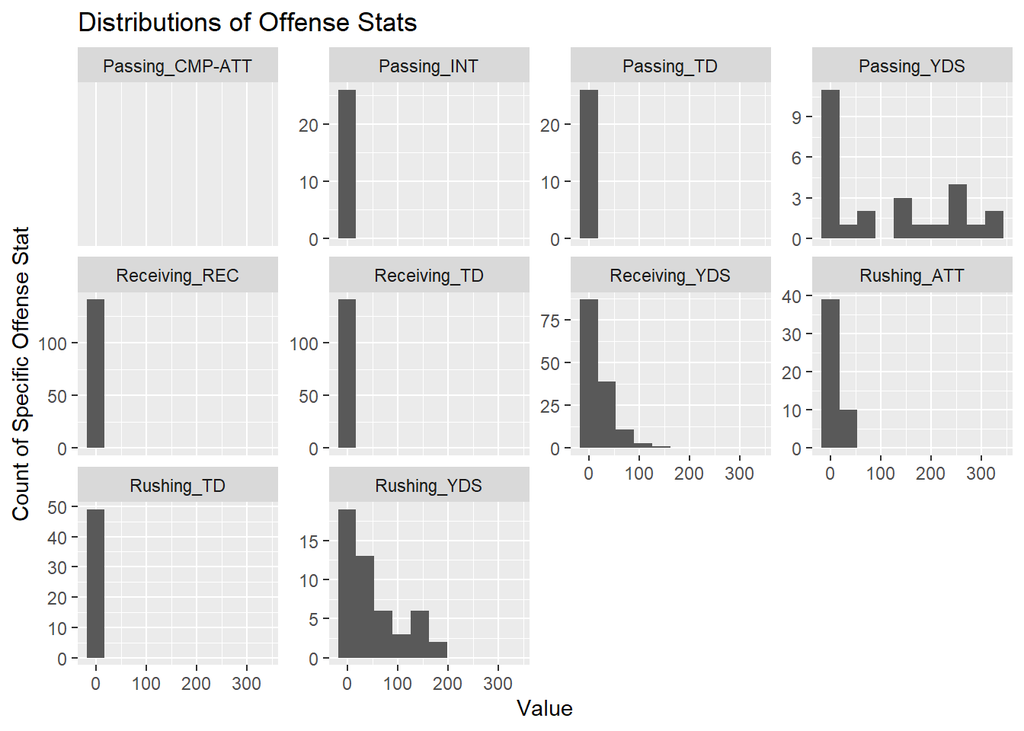

```r
p_two <- p_one %>%
      ggplot(aes(x = Value)) + geom_histogram(bins = 10) + facet_wrap(~Stat, scales = 'free_y')

p_two + ggtitle('Distributions of Offense Stats') + ylab("Count of Specific Offense Stat") + xlab("Value")
```

**3.** Did ISU have better offense against Oregon or Oklahoma? Answer this question by creating a scatter plot with the x- and y-axes being the receiving yards of the ISU players against these two opponents. A large number of receiving yards indicates good offense.

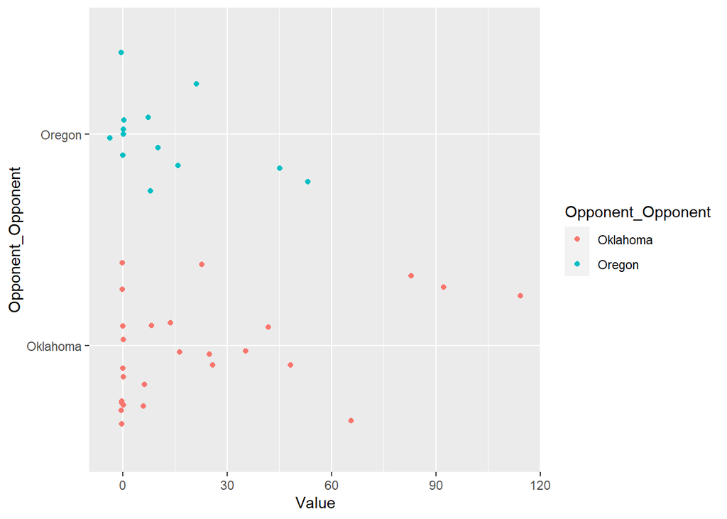

```r
#Not sure if I did this correctly
p_three <- p_one %>%
         select(Opponent_Opponent, Stat, Value) %>%
         filter(Opponent_Opponent == 'Oklahoma' | Opponent_Opponent == 'Oregon', Stat == 'Receiving_YDS') %>%
         ggplot(aes(x = Value, y = Opponent_Opponent, color = Opponent_Opponent)) + geom_point(position = 'jitter')

p_three
```

From this graph, it looks like Iowa State’s Offense did a lot better against Oklahoma than Oregon.

**4.** Separate the Hometown column into two columns, namely, the city and the state where the player comes from. Print the first few rows of these two columns. (Hint: look at the sep= argument of separate)

```r
p_four <- bioClean %>%
      separate(Hometown, into = c('City', 'State'), sep = ',')

head(select(p_four, Name, City, State))
```

```
## # A tibble: 6 x 3
##   Name                 City           State
##   <fct>                <chr>          <chr>
## 1 Akers, Landen        Cedar Rapids   " Iowa"
## 2 Allen, Chase         Nixa           " Mo."
## 3 Anderson, Ezeriah    Seffner        " Fla."
## 4 Antoine Jr. , Michal Ft. Lauderdale " Fla."
## 5 Assalley, Connor     Naperville     " Ill."
## 6 Azunna, Arnold       Grand Prairie  " Texas"
```

**5.** How many players are there from each state?

```r
p_five <- p_four %>%
      group_by(State) %>%
      summarise(Players = n())

p_five
```

```
## # A tibble: 21 x 2
##    State        Players
##  * <chr>          <int>
##  1 " Ariz."           4
##  2 " Ark."            1
##  3 " Australia"       1
##  4 " Calif."          2
##  5 " Fla."           14
##  6 " Ga."             3
##  7 " Ill."            6
##  8 " Iowa"           42
##  9 " Kan."            4
## 10 " Mich"            1
## # ... with 11 more rows
```

## Part 3: Joining Data Frames

**1.** Find which states do the ISU players (both defensive and offensive) come from. Create an appropriate numerical or graphical summary.

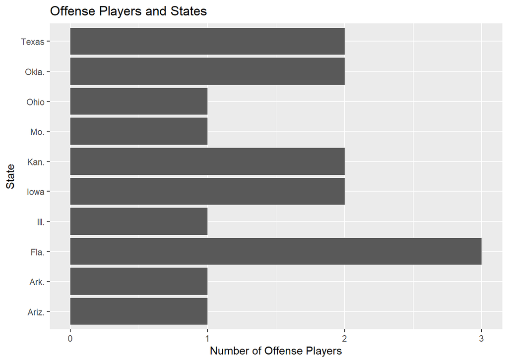

```r
#Offense
offState <- offClean %>%
      distinct(Name) %>%
      left_join(p_four, by = c("Name" = "Name"))

offState %>%
      group_by(State) %>%
      summarize(Players = n()) %>%
      ggplot(aes(x = State, weight = Players)) + geom_bar() + coord_flip() +
      ggtitle("Offense Players and States") + ylab("Number of Offense Players")
```

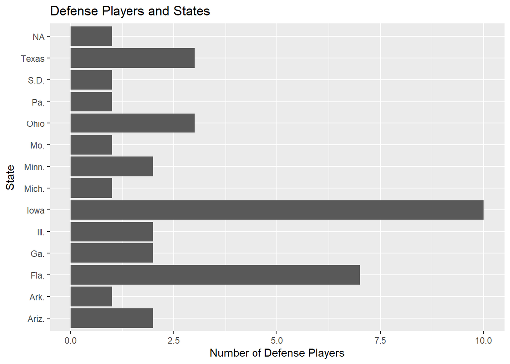

```r
#Defense
defState <- defClean %>%
      distinct(Name) %>%
      left_join(p_four, by = c("Name" = "Name"))

defState %>%
      group_by(State) %>%
      summarize(Players = n()) %>%
      ggplot(aes(x = State, weight = Players)) + geom_bar() + coord_flip() +
      ggtitle("Defense Players and States") + ylab("Number of Defense Players")
```